# rollupTree

# Overview

`rollupTree` implements a general function for computations in which some property of a parent element is a combination of corresponding properties of its child elements. The mass of an assembly, for example, is the sum of the masses of its subassemblies, and the mass of each subassembly is the sum of masses of its parts, etc.

`rollupTree` can perform computations specified by arbitrarily-shaped (but well-formed) trees, arbitrarily-defined properties and property-combining operations. Defaults are provided to simplify common cases (atomic numerical properties combined by summing), but functional programming techniques allow the caller to pass arbitrary *update* methods as required.

Despite its name, rollupTree can operate on directed acyclic graphs that are not trees if instructed to apply less stringent validation rules to its input. See `default_validate_dag()` and `rollup()`.

# Example With A Data Frame

Consider this example Work Breakdown Structure from [WorkBreakdownStructure.com](https://www.workbreakdownstructure.com):

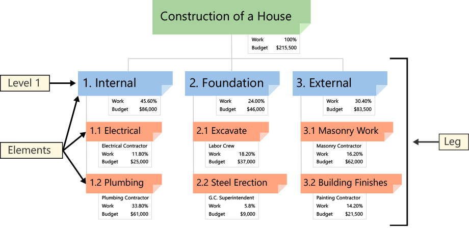

The computations in the example are worked out already; we show here how to reproduce them.

A Work Breakdown Structure is a tree, that is, a graph that is connected and acyclic. It is, in addition, directed, that is, the edges have direction. We arbitrarily chose the edge direction to go from child to parent. Finally, it is single-rooted: every vertex but one has a single parent vertex; the root vertex has no parent.

The leaf elements (vertices) of the tree require asserted values for the properties (work, budget) of interest. Property values for non-leaf elements are computed by `rollup()`.

We begin by capturing the structure of the tree and asserted values in a data frame we call `wbs_table`. Values to be computed are initially unknown. Each element is uniquely identified by an `id` column[^1]. We also indicate parent id in the `pid` column but this information is not used directly by `rollup()`.

```r
library(rollupTree)
wbs_table
```

```
#>     id  pid                    name work budget
#> 1  top <NA> Construction of a House   NA     NA
#> 2    1  top                Internal   NA     NA
#> 3    2  top              Foundation   NA     NA
#> 4    3  top                External   NA     NA
#> 5  1.1    1              Electrical 11.8  25000
#> 6  1.2    1                Plumbing 33.8  61000
#> 7  2.1    2                Excavate 18.2  37000
#> 8  2.2    2          Steel Erection  5.8   9000
#> 9  3.1    3            Masonry Work 16.2  62000
#> 10 3.2    3       Building Finishes 14.2  21500
```

A key feature of recursively-defined problems like this is that the computation for a given element must occur after properties for it children are known (either asserted or computed). Traversing a tree in this manner can be achieved by using a well-known algorithm in graph theory known as *topological sort*. For that reason, we construct an `igraph` (Csárdi et al. 2025) graph object in R, from which we can conveniently (1) check that the graph is in fact a well-formed tree, and (2) efficiently execute a topological sort to order the computations. (Note that, although the problems solved by rollup are *defined* recursively, the implementation in software is not recursive.)

It is a simple matter to construct a graph from the information in our data frame:

```r
library(rollupTree)
wbs_tree <- create_rollup_tree(
  get_keys = function() wbs_table$id,
  get_parent_key_by_child_key = function(key) wbs_table[wbs_table$id == key, "pid"]
)
```

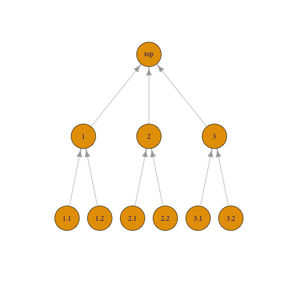

A directed acyclic graph may have more than one topological sort; any is suitable for our purpose. Here is what `rollup()` uses internally:

```r
igraph::topo_sort(wbs_tree)
```

```
#> + 10/10 vertices, named, from d3b941a:
#>  [1] 1.1 1.2 2.1 2.2 3.1 3.2 1   2   3   top
```

## Summing a Single Numeric Property

Although our data in this first example is a data frame, `rollup()` can operate on an arbitrary R object if provided with *update* and *validate* methods for that object. For the common case in which the parameter of interest is a numeric column in a data frame, the combine operation is addition, and the key column is named `id`, the package provides `update_df_prop_by_id()` and `validate_df_by_id()` functions that can be invoked as boilerplate. To roll up the `work` property, for example, we simply invoke:

```r
rollup(
  tree=wbs_tree,
  ds=wbs_table,
  update=function(d, t, s) update_df_prop_by_id(df=d, target=t, sources=s, prop="work"),
  validate_ds=function(t, d) validate_df_by_id(tree=t, df=d, prop="work")
)
```

```
#>     id  pid                    name  work budget
#> 1  top <NA> Construction of a House 100.0     NA
#> 2    1  top                Internal  45.6     NA
#> 3    2  top              Foundation  24.0     NA
#> 4    3  top                External  30.4     NA
#> 5  1.1    1              Electrical  11.8  25000
#> 6  1.2    1                Plumbing  33.8  61000
#> 7  2.1    2                Excavate  18.2  37000
#> 8  2.2    2          Steel Erection   5.8   9000
#> 9  3.1    3            Masonry Work  16.2  62000
#> 10 3.2    3       Building Finishes  14.2  21500
```

## Chaining Rollups

If we want to roll up the `budget` column as well, we can simply chain two `rollup()`s together. In this example we use R’s pipe operator:

```r
rollup(
  tree=wbs_tree,
  ds=wbs_table,
  update=function(d, t, s) update_df_prop_by_id(df=d, target=t, sources=s, prop="work"),
  validate_ds=function(t, d) validate_df_by_id(tree=t, df=d, prop="work")
) |> rollup(
  tree=wbs_tree,
  ds=_,
  update=function(d, t, s) update_df_prop_by_id(df=d, target=t, sources=s, prop="budget"),
  validate_ds=function(t, d) validate_df_by_id(tree=t, df=d, prop="budget")
)
```

```
#>     id  pid                    name  work budget
#> 1  top <NA> Construction of a House 100.0 215500
#> 2    1  top                Internal  45.6  86000
#> 3    2  top              Foundation  24.0  46000
#> 4    3  top                External  30.4  83500
#> 5  1.1    1              Electrical  11.8  25000
#> 6  1.2    1                Plumbing  33.8  61000
#> 7  2.1    2                Excavate  18.2  37000
#> 8  2.2    2          Steel Erection   5.8   9000
#> 9  3.1    3            Masonry Work  16.2  62000
#> 10 3.2    3       Building Finishes  14.2  21500
```

In most cases, this approach suffices. The code is simple and clear, and performance is not typically an issue. (In other testing `rollup()` performs tens of thousands of non-trivial property updates per second.) We show here some alternate approaches, mainly to illustrate architectural features of the approach that may be useful for more esoteric applications.

## Chaining Update Methods

`update_df_prop_by_id()` (like every well-behaved *update* method) modifies only the specified column and leaves the rest of the data frame unchanged, so we can chain two updates within a single `rollup()` instead of chaining two `rollup()`s. Similarly, a data set validator returns a logical value, so we can make the conjunction of two validators:

```r
rollup(
  tree = wbs_tree,
  ds = wbs_table,
  update = function(d, t, s) {
    update_df_prop_by_id(
      df = d,
      target = t,
      sources = s,
      prop = "work"
    ) |>
      update_df_prop_by_id(target = t,
                           sources = s,
                           prop = "budget")
  },
  validate_ds = function(t, d) {
    validate_df_by_id(tree = t, df = d, prop = "work") &&
      validate_df_by_id(tree = t, df = d, prop = "budget")
  }
)
```

```
#>     id  pid                    name  work budget
#> 1  top <NA> Construction of a House 100.0 215500
#> 2    1  top                Internal  45.6  86000
#> 3    2  top              Foundation  24.0  46000
#> 4    3  top                External  30.4  83500
#> 5  1.1    1              Electrical  11.8  25000
#> 6  1.2    1                Plumbing  33.8  61000
#> 7  2.1    2                Excavate  18.2  37000
#> 8  2.2    2          Steel Erection   5.8   9000
#> 9  3.1    3            Masonry Work  16.2  62000
#> 10 3.2    3       Building Finishes  14.2  21500
```

## Custom *get*, *set*, and *update* Methods

In this example we create a custom *get* method that builds a named vector from the specified properties (using lower-level function `df_get_by_id()`) and a corresponding *set* method (using `df_set_by_id()`). We then create a custom *update* method using these methods. (The default *combine* method still works because R knows how to add vectors.) Finally, we create a custom data set validator and invoke `rollup()` with our custom methods.

```r
my_get <- function(d, i) c(
  w=df_get_by_id(df=d, id=i, prop="work"),
  b=df_get_by_id(df=d, id=i, prop="budget")
)
my_set <- function(d, i, v) {
  df_set_by_id(df=d, id=i, prop="work", val=v["w"]) |>
    df_set_by_id(id=i, prop="budget", val=v["b"])
}
my_update <- function(d, t, s) {
    update_prop(ds=d, target=t, sources=s, set=my_set, get=my_get)
}
my_validate <- function(t, d) {
  validate_ds(tree=t, ds=d,
               get_keys=function(d) df_get_ids(df=d),
               get_prop=my_get,
               op=function(v) my_check(v["w"]) && my_check(v["b"])
  )
}
my_check <- function(v)
  is.numeric(v) && !is.na(v) && (v > 0.0)

rollup(
  tree = wbs_tree,
  ds = wbs_table,
  update = my_update,
  validate_ds = my_validate
)
```

```
#>     id  pid                    name  work budget
#> 1  top <NA> Construction of a House 100.0 215500
#> 2    1  top                Internal  45.6  86000
#> 3    2  top              Foundation  24.0  46000
#> 4    3  top                External  30.4  83500
#> 5  1.1    1              Electrical  11.8  25000
#> 6  1.2    1                Plumbing  33.8  61000
#> 7  2.1    2                Excavate  18.2  37000
#> 8  2.2    2          Steel Erection   5.8   9000
#> 9  3.1    3            Masonry Work  16.2  62000
#> 10 3.2    3       Building Finishes  14.2  21500
```

## Custom *combine* Method

Finally, we illustrate the use of a custom combiner. Suppose we have 5% uncertainty in our leaf cost numbers. Add those uncertainty numbers to our data frame:

```r
new_wbs_table <- wbs_table
new_wbs_table$work <- NULL
new_wbs_table$budget_unc <- ifelse(is.na(wbs_table$budget), NA, wbs_table$budget * 0.05)
new_wbs_table
```

```
#>     id  pid                    name budget budget_unc
#> 1  top <NA> Construction of a House     NA         NA
#> 2    1  top                Internal     NA         NA
#> 3    2  top              Foundation     NA         NA
#> 4    3  top                External     NA         NA
#> 5  1.1    1              Electrical  25000       1250
#> 6  1.2    1                Plumbing  61000       3050
#> 7  2.1    2                Excavate  37000       1850
#> 8  2.2    2          Steel Erection   9000        450
#> 9  3.1    3            Masonry Work  62000       3100
#> 10 3.2    3       Building Finishes  21500       1075
```

The standard technique for accumulating uncertainties is to combine using root-sum-square (RSS).

```r
combine_rss <- function(vl) {
  sqrt(Reduce(f = `+`, x = Map(
    f = function(v)
      v * v,
    vl
  )))
}
result <- rollup(
  tree = wbs_tree,
  ds = new_wbs_table,
  update = function(d, t, s)
    update_df_prop_by_id(
      df = d,
      target = t,
      sources = s,
      prop = "budget"
    ) |>
    update_df_prop_by_id(
      target = t,
      sources = s,
      prop = "budget_unc",
      combine = combine_rss
    ),
  validate_ds = function(t, d)
    validate_df_by_id(tree = t, df = d, prop = "budget_unc"),
)
result$budget_unc_pct <- result$budget_unc / result$budget * 100.
result
```

```
#>     id  pid                    name budget budget_unc budget_unc_pct
#> 1  top <NA> Construction of a House 215500   5025.497       2.332017
#> 2    1  top                Internal  86000   3296.210       3.832802
#> 3    2  top              Foundation  46000   1903.943       4.139007
#> 4    3  top                External  83500   3281.101       3.929462
#> 5  1.1    1              Electrical  25000   1250.000       5.000000
#> 6  1.2    1                Plumbing  61000   3050.000       5.000000
#> 7  2.1    2                Excavate  37000   1850.000       5.000000
#> 8  2.2    2          Steel Erection   9000    450.000       5.000000
#> 9  3.1    3            Masonry Work  62000   3100.000       5.000000
#> 10 3.2    3       Building Finishes  21500   1075.000       5.000000
```

# Example With A List

Suppose instead of a data frame we have a list of lists:

```r
wbs_list <- lapply(split(wbs_table, wbs_table$id),
                   function(r) list(name = r$name, budget = r$budget)
)
str(wbs_list)
```

```
#> List of 10
#>  $ 1  :List of 2
#>   ..$ name  : chr "Internal"
#>   ..$ budget: num NA
#>  $ 1.1:List of 2
#>   ..$ name  : chr "Electrical"
#>   ..$ budget: num 25000
#>  $ 1.2:List of 2
#>   ..$ name  : chr "Plumbing"
#>   ..$ budget: num 61000
#>  $ 2  :List of 2
#>   ..$ name  : chr "Foundation"
#>   ..$ budget: num NA
#>  $ 2.1:List of 2
#>   ..$ name  : chr "Excavate"
#>   ..$ budget: num 37000
#>  $ 2.2:List of 2
#>   ..$ name  : chr "Steel Erection"
#>   ..$ budget: num 9000
#>  $ 3  :List of 2
#>   ..$ name  : chr "External"
#>   ..$ budget: num NA
#>  $ 3.1:List of 2
#>   ..$ name  : chr "Masonry Work"
#>   ..$ budget: num 62000
#>  $ 3.2:List of 2
#>   ..$ name  : chr "Building Finishes"
#>   ..$ budget: num 21500
#>  $ top:List of 2
#>   ..$ name  : chr "Construction of a House"
#>   ..$ budget: num NA
```

We construct *update* and *validate* functions as follows:

```r
list_get <- function(d, i) d[[i]]$budget
list_set <- function(d, i, v) { d[[i]]$budget = v; d }
list_update <- function(d, t, s) { update_prop(d, t, s, list_set, list_get) }
list_validate <- function(t, d) validate_ds(t, d, get_keys = function(l) names(l), get = list_get)
```

The output of `rollup()` is as expected:

```r
list_result <- rollup(wbs_tree, wbs_list, list_update, list_validate)
str(list_result)
```

```
#> List of 10
#>  $ 1  :List of 2
#>   ..$ name  : chr "Internal"
#>   ..$ budget: num 86000
#>  $ 1.1:List of 2
#>   ..$ name  : chr "Electrical"
#>   ..$ budget: num 25000
#>  $ 1.2:List of 2
#>   ..$ name  : chr "Plumbing"
#>   ..$ budget: num 61000
#>  $ 2  :List of 2
#>   ..$ name  : chr "Foundation"
#>   ..$ budget: num 46000
#>  $ 2.1:List of 2
#>   ..$ name  : chr "Excavate"
#>   ..$ budget: num 37000
#>  $ 2.2:List of 2
#>   ..$ name  : chr "Steel Erection"
#>   ..$ budget: num 9000
#>  $ 3  :List of 2
#>   ..$ name  : chr "External"
#>   ..$ budget: num 83500
#>  $ 3.1:List of 2
#>   ..$ name  : chr "Masonry Work"
#>   ..$ budget: num 62000
#>  $ 3.2:List of 2
#>   ..$ name  : chr "Building Finishes"
#>   ..$ budget: num 21500
#>  $ top:List of 2
#>   ..$ name  : chr "Construction of a House"
#>   ..$ budget: num 215500
```

# Example With A Tree

The tree can serve as the dataset with proper attributes and methods. To illustrate, we add the budget figures from our data frame as vertex attributes to the tree:

```r
library(igraph)
new_wbs_tree <- Reduce(
  f = function(g, k) set_vertex_attr(g, 'budget', k, df_get_by_id(wbs_table, k, 'budget')),
  x = names(V(wbs_tree)),
  init = wbs_tree
)
ib <- vertex_attr(new_wbs_tree, "budget")
names(ib) <- names(V(new_wbs_tree))
ib
```

```
#>   top     1     2     3   1.1   1.2   2.1   2.2   3.1   3.2
#>    NA    NA    NA    NA 25000 61000 37000  9000 62000 21500
```

We construct *update* and *validate* functions as follows:

```r
tree_get <- function(d, k) vertex_attr(d, "budget", k)
tree_set <- function(d, k, v) set_vertex_attr(d, "budget", k, v)
tree_update <- function(d, t, s) update_prop(d, t, s, set = tree_set, get = tree_get)
tree_validate <- function(t, d) validate_ds(t, d, get_keys = function(d) names(V(d)), get = tree_get)
```

The output of `rollup()` is as expected:

```r
tree_result <- rollup(new_wbs_tree, new_wbs_tree, update = tree_update, validate_ds = tree_validate)
ob <- vertex_attr(tree_result, "budget")
names(ob) <- names(V(tree_result))
ob
```

```
#>    top      1      2      3    1.1    1.2    2.1    2.2    3.1    3.2
#> 215500  86000  46000  83500  25000  61000  37000   9000  62000  21500
```

# Simple Fault Tree Analysis

Fault tree analysis is similarly recursive. We show here a greatly-simplified (Devasia 2021) example to illustrate a particular feature of the implementation.

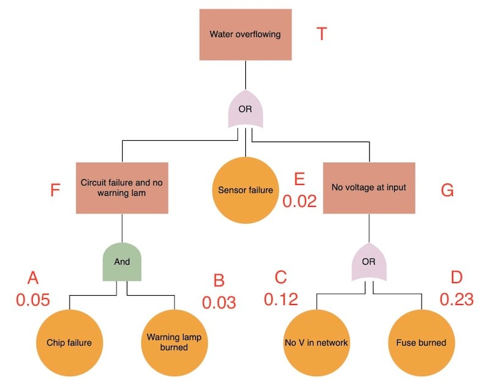

https://control.com/technical-articles/deep-dive-into-fault-tree-analysis/

For the purpose of illustration, we make the following simplifying assumptions:

- Every gate is associated with an intermediate event, and each gate/event pair can be represented by a single vertex in the tree.
- Only gates of type AND and OR are permitted.

Our initial fault properties table is:

```
#>                                    id  type prob
#> 1                   Water overflowing    or   NA
#> 2 Circuit failure and no warning lamp   and   NA
#> 3                      Sensor failure basic 0.02
#> 4                 No voltage at input    or   NA
#> 5                        Chip failure basic 0.05
#> 6                 Warning lamp burned basic 0.03
#> 7                     No V in network basic 0.12
#> 8                         Fuse burned basic 0.23
```

The edge list of the fault tree is:

```
#> + 7/7 edges from 2d2da5d (vertex names):
#> [1] Circuit failure and no warning lamp->Water overflowing
#> [2] Sensor failure                     ->Water overflowing
#> [3] No voltage at input                ->Water overflowing
#> [4] Chip failure                       ->Circuit failure and no warning lamp
#> [5] Warning lamp burned                ->Circuit failure and no warning lamp
#> [6] No V in network                    ->No voltage at input
#> [7] Fuse burned                        ->No voltage at input
```

Get and set methods for this example are simple and obvious:

```r
df_get_fault_props <- function(df, id) {
  list(
    type = df_get_by_id(df, id, "type"),
    prob = df_get_by_id(df, id, "prob")
  )
}

df_set_fault_props <- function(df, id, v) {
  df_set_by_id(df, id, "prob", v$prob)
}
```

In most applications (e.g., mass properties), the combining operation only the values to be combined, and is therefore passed only those values as input. In the case of a fault tree, however, the input for an AND gate are multiplied, whereas for an OR gate are summed. We can accommodate this situation by passing an optional *type* argument to the combiner follows:

```r
combine_fault_props <- function(vl, type) {
  list(
    prob = Reduce(
      f = if (type == "and") "*" else "+",
      Map(f = function(v) v$prob, vl)
    )
  )
}

update_fault_props <- function(ds, parent_key, child_keys) {
  update_prop(
    ds,
    target = parent_key,
    sources = child_keys,
    set = df_set_fault_props,
    get = df_get_fault_props,
    combine = function(vl)
      combine_fault_props(vl, df_get_fault_props(ds, parent_key)$type)
  )
}

validate_fault_props <- function(fp) {
  if (fp$type != "basic") stop(sprintf("invalid leaf node type %s", fp$type))
  if (!is.numeric(fp$prob) || fp$prob < 0.0 || fp$prob > 1.0)
    stop(sprintf("invalid probability value %f", fp$prob))
  TRUE
}

validate_fault_props_table <- function(tree, df) {
  validate_ds(tree, df, df_get_ids, df_get_fault_props, validate_fault_props)
}
```

Calling `rollup()` in the usual manner yields:

```
#>                                    id  type   prob
#> 1                   Water overflowing    or 0.3715
#> 2 Circuit failure and no warning lamp   and 0.0015
#> 3                      Sensor failure basic 0.0200
#> 4                 No voltage at input    or 0.3500
#> 5                        Chip failure basic 0.0500
#> 6                 Warning lamp burned basic 0.0300
#> 7                     No V in network basic 0.1200
#> 8                         Fuse burned basic 0.2300
```

# References

Csárdi, Gábor, Tamás Nepusz, Vincent Traag, Szabolcs Horvát, Fabio Zanini, Daniel Noom, and Kirill Müller. 2025. *igraph: Network Analysis and Visualization in r*. https://doi.org/10.5281/zenodo.7682609.

Devasia, Anish. 2021. “Deep Dive into Fault Tree Analysis.” 2021. https://control.com/technical-articles/deep-dive-into-fault-tree-analysis/.

[^1]: `id` is the default but any valid column name can be used. Values should be character data.